# AirQualityViewer Spain

Rafael Daniel

May 27th 2017

# Why AirQualityViewer?

- Did you ever wonder which is the quality of the air that you breath?
- With this Shinny app you will be able to view the data published by the European Environmental Agency about 94 air pollutants aggregated by 33 different ways.
- Select the station closer to your home and check what is measured and which are the values compared to other stations.
- Look at the evolution of the pollutants levels from year to year.

### About the data:

- Air Quality Viewer allows to navigate through the data posted by [European Environmental Agency](http://aidef.apps.eea.europa.eu/?source=%7B%22query%22:%7B%22bool%22:%7B%22must%22:%5B%7B%22term%22:%7B%22CountryOrTerritory%22:%22Spain%22%7D%7D%5D%7D%7D,%22display_type%22:%22tabular%22%7D) about the air pollutants.
- Data was dowloaded on May 27th of 2017 and uploaded to the shinny app server.
- Data is also available on [GitHub repository](https://github.com/rafeldaniel/AirQualitySpain/commit/92a8710642f8aba46e35734ad7ded0497a59bf1b) for this app.

# How to use AirQualityViewer - Selecting Data

1. Get to the application by naviating to https://rafeldaniel.shinyapps.io/AirQualitySpain/
2. On the right side select the year range you want to analyse with the slider (from to dates are allowed). Notice that not all the pollutants are measured in all the stations all the years.
3. Select the pollutant you are interested on from the list of pollutants. For example Sulphur dioxide (air)
4. Select the aggregation type from the available aggregation types provided by the European Environmental Agency for this pollutant, this list is different for each pollutant type.
5. Units available (if more than one) can be selected in select unit list.
6. Selected station shows you that currently ALL the available stations that are measure this pollutant are selected. Click on one station to select it, click on the marker to unselect

# How to use AirQualityViewer - The plots

1. The map will show the average measurement across all the selected years, lower values are colored in green and higher values in read.
2. The histogram shows the means recorded by each station in the selected years. Median and mean vertical lines are displayed, the selected station mean measures are also markt with a vertical line.

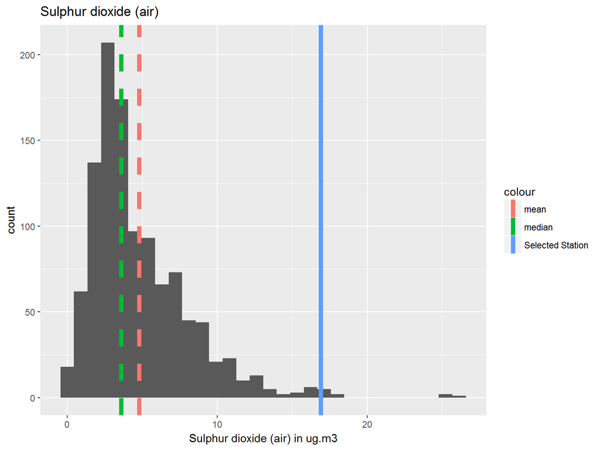

# How to use AirQualityViewer - The plots

3. The box plot shows the boxplot of the selected pollutant and aggregation type regardless the selected year. The average overall the Station measures tendacy is also represented.
4. When selected the average measures of the selected station is also shown.

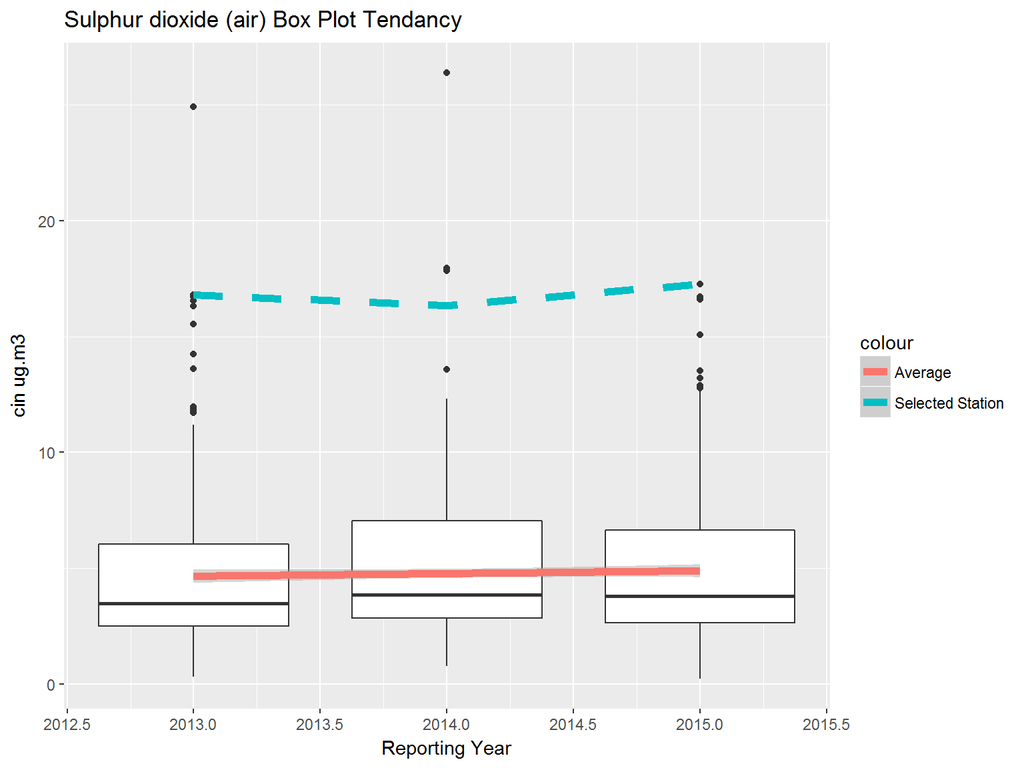